# Class Activity: polynomial regression

In this activity, you will explore polynomial regression with data on CO2 emissions in Germany.

**Instructions:**

- You are welcome to work with a neighbor, but everyone must submit their own file to Canvas
- At the end of class, render the file as an HTML and submit the HTML to Canvas (let me know if you encounter any problems)

## Setup

**Template file:** ca_11_template.qmd

The data is contained in the `CO2Germany` dataset in the `Stat2Data` package. You can load the data by running the following:

```r
library(Stat2Data)
data("CO2Germany")
```

The `CO2Germany` contains two variables: `CO2` (the CO2 level in ppm) and `Day` (the number of day in 2011).

## Question

Here’s a plot showing the relationship between Day and CO2:

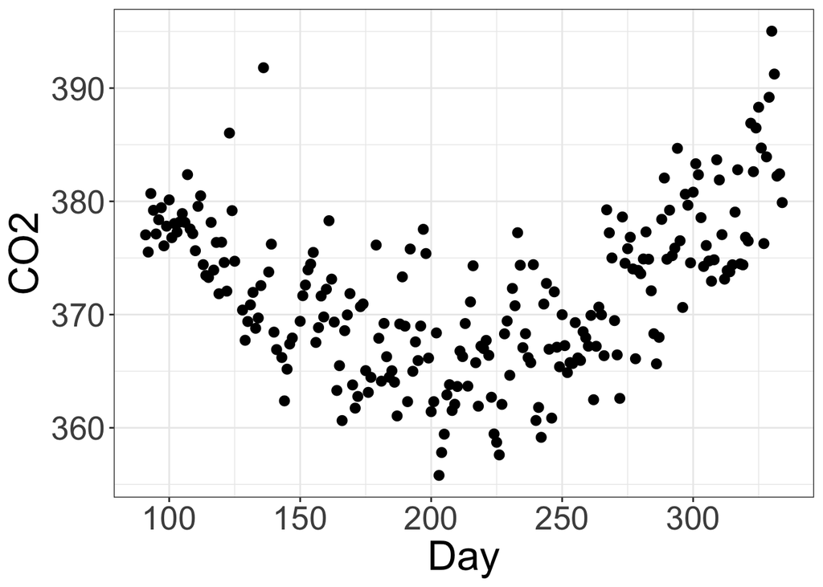

1. Fit a polynomial regression of order 2, with Day as the predictor and CO2 as the response.

```r
lm(... ~ poly(..., ..., raw=TRUE), data = ...)
```

2. Based on the fitted model, is the relationship between Day and CO2 concave up or concave down?
3. What is the predicted CO2 level for day 200?

The figure below shows our fitted model (the blue curve) on the original scatterplot. We also try a polynomial of order 3 (the red dashed curve).

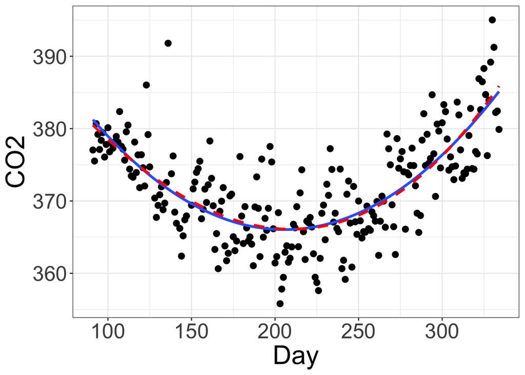

4. Does a polynomial of order 3 look like it fits better?